# Statistical learning: Multinomial Logistic Regression, LDA, QDA and Naive Bayes

Author

Patricia Cabezón Díez - Olaya González Campos - Naroa Martín Casado

# Introduction

This project is based on a health-related dataset obtained from the UCI Machine Learning Repository. The dataset contains demographic information, lifestyle indicators, and medical risk factors associated with diabetes. Among the available variables, we find measures such as blood pressure, cholesterol levels, body mass index (BMI), physical activity, dietary habits, general health condition, and several socioeconomic characteristics.

The response variable of interest is `Diabetes_012`, a multicategorical outcome variable that distinguishes between individuals with no diabetes, prediabetes, and diagnosed diabetes. Therefore, the problem is formulated as a multiclass classification task.

The main objective of this study is to predict the target variable using the available predictors. To accomplish this goal, we will first focus on data preparation and preprocessing, ensuring appropriate data cleaning, variable transformation, and correct handling of categorical and numerical features.

Next, we will conduct an Exploratory Data Analysis (EDA) to better understand the structure of the dataset, analyze the distribution of the variables, and identify the main predictors affecting the target variable.

Finally, we will apply probabilistic learning methods to model the relationship between the explanatory variables and the response variable. The aim is not only to build accurate predictive models, but also to gain insight into the key health and lifestyle factors associated with different diabetes conditions.

## Required Libraries

We load the needed libraries and also a workspace called `workspace.RData` that contains some R objects that will allow us to generate the final pdf using `Quarto` without having to run the functions that take very times to run.

```r
rm(list = ls()) # Clean environment
#Upload packages
library(tidyverse)
library(corrplot)
library(gridExtra)
library(scales)
library(MASS)         # LDA and QDA
library(e1071)        # Naive Bayes
library(caret)        # Model training and evaluation
library(klaR)         # Visualization of classification boundaries
library(ggplot2)
library(GGally)
library(patchwork)
library(nnet)
library(effectsize)
library(dplyr)
library(ggplot2)
library(rcompanion)
library(tidyr)
library(tibble)
library(naivebayes)
library(pROC)
```

```r
load("workspace_final.RData")
```

# Dataset Overview

## General Structure

We begin by examining the general structure of the dataset, including the number of observations and variables.

```r
#Upload the dataset
data <- read.csv("dataset_diabetes.csv", stringsAsFactors=TRUE)
```

```r
# Number of observations and variables
n_obs <- nrow(data)
n_vars <- ncol(data)

cat("The dataset contains", n_obs, "observations and",
    n_vars, "variables.\n")
```

```
The dataset contains 253680 observations and 22 variables.
```

It can be seen that the dataset contains 253,680 observations and 22 variables. Before proceeding with the modeling stage, it is essential to examine the type of each variable to ensure that they are handled appropriately. If the imported dataset does not accurately reflect the true nature of the variables, we transform them accordingly so that they are properly encoded for subsequent analysis.

The response variable, `Diabetes_012`, is a factor with three levels, corresponding to the three diabetes categories (No Diabetes, Prediabetes, and Diabetes). Several predictors such as `HighBP`, `HighChol`, `CholCheck`, `Smoker`, `Stroke`, `HeartDiseaseorAttack`, `PhysActivity`, `Fruits`, `Veggies`, `HvyAlcoholConsump`, `AnyHealthcare`, `NoDocbcCost`, `DiffWalk`, and `Sex` are binary categorical variables coded as factors with two levels (0/1).

Other predictors, such as `BMI`, `MentHlth`, and `PhysHlth`, are numeric variables and can be treated as continuous. Additionally, variables like `Age`, `Education`, and `Income` are ordinal factors, meaning that their categories follow a natural ordering and should be treated accordingly in the analysis.

```r
# Define variable groups
binary_vars <- c('HighBP', 'HighChol','CholCheck','Smoker',
                 'Stroke','HeartDiseaseorAttack','PhysActivity',
                 'Fruits','Veggies','HvyAlcoholConsump',
                 'AnyHealthcare','NoDocbcCost','DiffWalk','Sex')

categorical_vars <- c('Diabetes_012','GenHlth','Age','Education',
                      'Income')

numeric_vars <- setdiff(names(data), c(binary_vars, categorical_vars))

# Count variables
n_binary <- length(binary_vars)
n_categorical <- length(categorical_vars)
n_numeric <- length(numeric_vars)

cat(sprintf("The dataset is composed of:\n\n"))
```

```
The dataset is composed of:
```

```r
cat(sprintf("- %d binary variables\n", n_binary))
```

```
- 14 binary variables
```

```r
cat(sprintf("- %d categorical (multiclass/ordinal) variables\n", n_categorical))
```

```
- 5 categorical (multiclass/ordinal) variables
```

```r
cat(sprintf("- %d numerical (continuous) variables\n", n_numeric))
```

```
- 3 numerical (continuous) variables
```

## Data Preparation: Factor Conversion

In this step, categorical and binary variables are converted into factors. This transformation ensures that R correctly treats these variables as categorical instead of numerical during the modeling process.

Additionally, ordinal variables such as `Age`, `Education`, and `Income` are explicitly defined as ordered factors, preserving their natural ranking structure.

```r
vars_factor <- c('Diabetes_012', 'HighBP', 'HighChol','CholCheck','Smoker',
                 'Stroke','HeartDiseaseorAttack','PhysActivity', 'Fruits','Veggies',
                 'HvyAlcoholConsump', 'AnyHealthcare','NoDocbcCost','GenHlth',
                 'DiffWalk','Sex','Age','Education','Income')

# Convert selected variables to factors
data[vars_factor] <- lapply(data[vars_factor], as.factor)

# Define ordinal variables
data$Age <- ordered(data$Age)
data$Education <- ordered(data$Education)
data$Income <- ordered(data$Income)
```

## Missing Values

Before proceeding with the exploratory analysis and modeling stage, we check whether the dataset contains missing values. This step is important to ensure data quality and to decide if any imputation or filtering is required.

```r
na_total <- sum(is.na(data))
na_by_var <- colSums(is.na(data))

cat(sprintf("Total missing values in the dataset: %d\n\n", na_total))
```

```
Total missing values in the dataset: 0
```

```r
if (na_total == 0) {
  cat("No missing values were found in the dataset.\n")
} else {
  cat("Missing values by variable (only variables with NAs are shown):\n\n")
  print(na_by_var[na_by_var > 0])
}
```

```
No missing values were found in the dataset.
```

## Sample Dataset

As observed, the dataset contains 253,680 observations, which makes the computations slow due to the size of the data. To reduce runtime, we will work with a representative subsample of the dataset which contains 50,000 observations. Also, to ensure the reproducibility of the report regarding random proceedures (such as sampling), we use `set.seed()`.

```r
set.seed(1234)
df<- dplyr::sample_n(data, 50000)

# Number of observations and variables
n_obs <- nrow(df)
n_vars <- ncol(df)

cat("Now the dataset contains", n_obs, "observations and",
    n_vars, "variables.\n")
```

```
Now the dataset contains 50000 observations and 22 variables.
```

# Exploratory Data Analysis

## Target Variable: `Diabetes_012`

The response variable of interest in this study is `Diabetes_012`. This variable represents the diabetes status of each individual and defines the prediction task.

It is a multicategorical outcome variable with three possible classes:

- **0 — No diabetes**
- **1 — Prediabetes**
- **2 — Diagnosed diabetes**

Therefore, the modeling problem is formulated as a multiclass classification task, where the goal is to predict an individual’s diabetes status based on demographic, lifestyle, and health-related predictors.

Understanding the distribution of the target variable is essential, as potential class imbalance may affect both model performance and evaluation metrics. We begin by analyzing its frequency distribution.

```r
df %>%
  mutate(Diabetes_012 = factor(Diabetes_012,levels = c(0,1,2),
                               labels = c("No Diabetes",
                                          "Prediabetes",
                                          "Diabetes"))) %>%
  count(Diabetes_012, name = "Frequency")
```

```
  Diabetes_012 Frequency
1  No Diabetes     42028
2  Prediabetes       948
3     Diabetes      7024
```

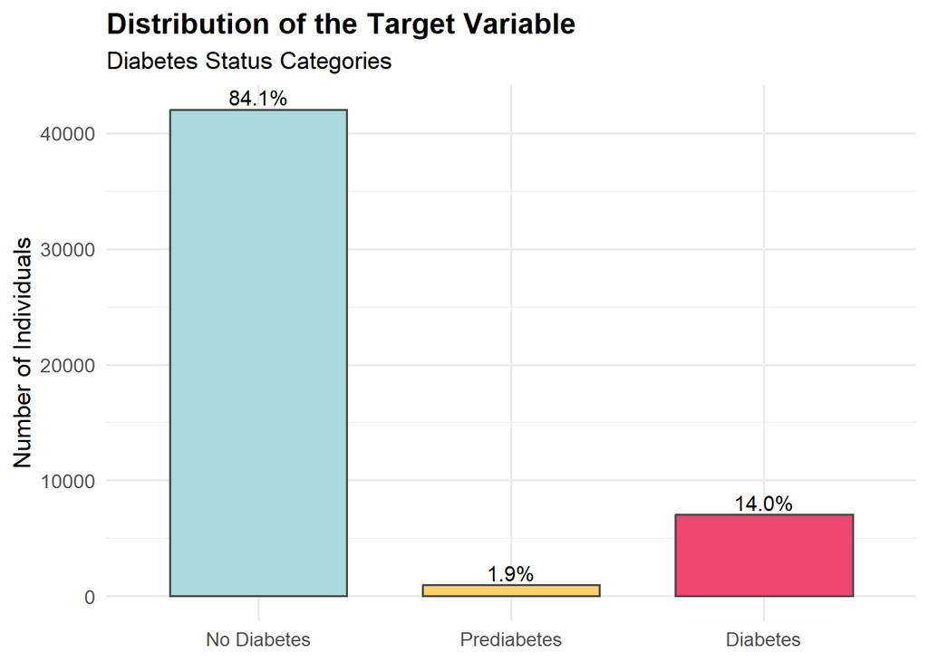

```r
# Create labeled version of the target variable
df_plot <- df %>%
  mutate(Diabetes_012 = factor(Diabetes_012,
                               levels = c(0,1,2),
                               labels = c("No Diabetes",
                                          "Prediabetes",
                                          "Diabetes")))

df_counts <- df_plot %>%
  count(Diabetes_012) %>%
  mutate(prop = n / sum(n))

ggplot(df_counts, aes(x = Diabetes_012, y = n, fill = Diabetes_012)) +
  geom_bar(stat = "identity", color = "grey30", width = 0.7) +
  geom_text(aes(label = percent(prop, accuracy = 0.1)),
            vjust = -0.3,
            size = 4) +
  scale_fill_manual(values = c("#A8DADC",
                               "#FFD166",
                               "#EF476F")) +
  labs(title = "Distribution of the Target Variable",
       subtitle = "Diabetes Status Categories",
       x = NULL,
       y = "Number of Individuals") +
  theme_minimal(base_size = 13) +
  theme(
    legend.position = "none",
    plot.title = element_text(face = "bold")
  )
```

From the distribution of the target variable, we observe that there is a clear class imbalance. The majority of individuals belong to the No Diabetes category, while the Prediabetes class is significantly underrepresented. The Diabetes category also represents a substantially smaller proportion compared to the majority class.

This imbalance may negatively affect the performance of standard classification algorithms, as many models tend to favor the majority class, potentially leading to biased predictions and poor detection of minority classes.

Therefore, it may be necessary to apply techniques to address class imbalance, such as resampling strategies in order to ensure more reliable and robust predictive performance across all classes.

## Numerical Variables Analysis

The dataset contains a small set of continuous numerical variables, namely:

- Body Mass Index (`BMI`)
- Number of days of poor mental health (`MentHlth`)
- Number of days of poor physical health (`PhysHlth`)

In order to evaluate their predictive potential, we analyze their distribution across the different categories of the target variable (`Diabetes_012`).

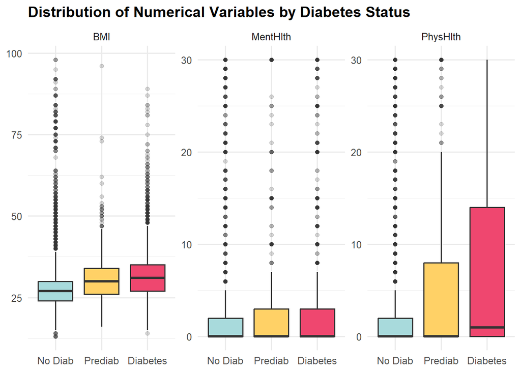

```r
num_vars <- c("BMI", "MentHlth", "PhysHlth")

df_long <- df %>%
  mutate(Diabetes_012 = factor(Diabetes_012,
                               levels = c(0,1,2),
                               labels = c("No Diab",
                                          "Prediab",
                                          "Diabetes"))) %>%
  pivot_longer(cols = all_of(num_vars),
               names_to = "Variable",
               values_to = "Value")

ggplot(df_long, aes(x = Diabetes_012, y = Value, fill = Diabetes_012)) +
  geom_boxplot(outlier.alpha = 0.2) +
  facet_wrap(~ Variable, scales = "free", ncol = 3) +
  scale_fill_manual(values = c("#A8DADC", "#FFD166", "#EF476F")) +
  labs(title = "Distribution of Numerical Variables by Diabetes Status",
       x = NULL,
       y = NULL) +
  theme_minimal(base_size = 12) +
  theme(legend.position = "none",
        plot.title = element_text(face = "bold"))
```

From the graphical analysis, Body Mass Index (BMI) shows a clear increasing trend across diabetes categories, with higher median values observed in the Diabetes group. This suggests that BMI could be a strong predictor of diabetes status.

Regarding mental health, the distributions are highly concentrated at zero and show substantial overlap across categories, indicating limited discriminative power.

Physical health exhibits greater variability in the Diabetes group and slightly higher central tendency, suggesting a moderate association with the target variable.

## Categorical and Binary Variables Analysis

We now analyze the relationship between binary and categorical predictors and the target variable (`Diabetes_012`).

Since these variables are categorical, we examine their conditional distribution across diabetes status using proportion-based bar plots. This allows us to assess whether the probability of belonging to a given diabetes category varies across levels of each predictor.

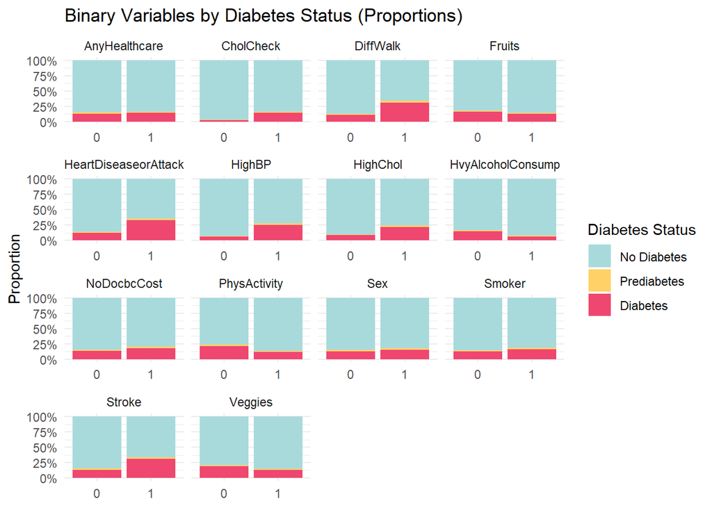

```r
binary_vars <- c('HighBP','HighChol','CholCheck','Smoker',
                 'Stroke','HeartDiseaseorAttack','PhysActivity',
                 'Fruits','Veggies','HvyAlcoholConsump',
                 'AnyHealthcare','NoDocbcCost','DiffWalk','Sex')

df$Diabetes_012 <- factor(df$Diabetes_012,
                          levels = c(0,1,2),
                          labels = c("No Diabetes",
                                     "Prediabetes",
                                     "Diabetes"))

df_long_bin <- df %>%
  pivot_longer(cols = all_of(binary_vars),
               names_to = "Variable",
               values_to = "Value") %>%
  mutate(Value = factor(Value))

ggplot(df_long_bin, aes(x = Value, fill = Diabetes_012)) +
  geom_bar(position = "fill") +
  facet_wrap(~ Variable, scales = "free_x", ncol = 4) +
  scale_y_continuous(labels = percent_format()) +
  scale_fill_manual(values = c("#A8DADC", "#FFD166", "#EF476F")) +
  labs(title = "Binary Variables by Diabetes Status (Proportions)",
       x = NULL,
       y = "Proportion",
       fill = "Diabetes Status") +
  theme_minimal(base_size = 11)
```

Several binary predictors exhibit strong associations with diabetes status. In particular, high blood pressure (HighBP), high cholesterol (HighChol), history of heart disease, stroke, and difficulty walking (DiffWalk) show substantial increases in the proportion of diagnosed diabetes when the condition is present.

In contrast, variables such as healthcare access, alcohol consumption, and smoking show weaker differences across categories, indicating a more limited discriminative capacity.

## Ordinal Variables Analysis

In addition to continuous predictors, the dataset contains several ordinal variables, namely `Age`, `Education`, and `Income`.

To evaluate their relationship with the target variable (`Diabetes_012`), we analyze the proportional distribution of diabetes status across the different levels of each ordinal predictor.

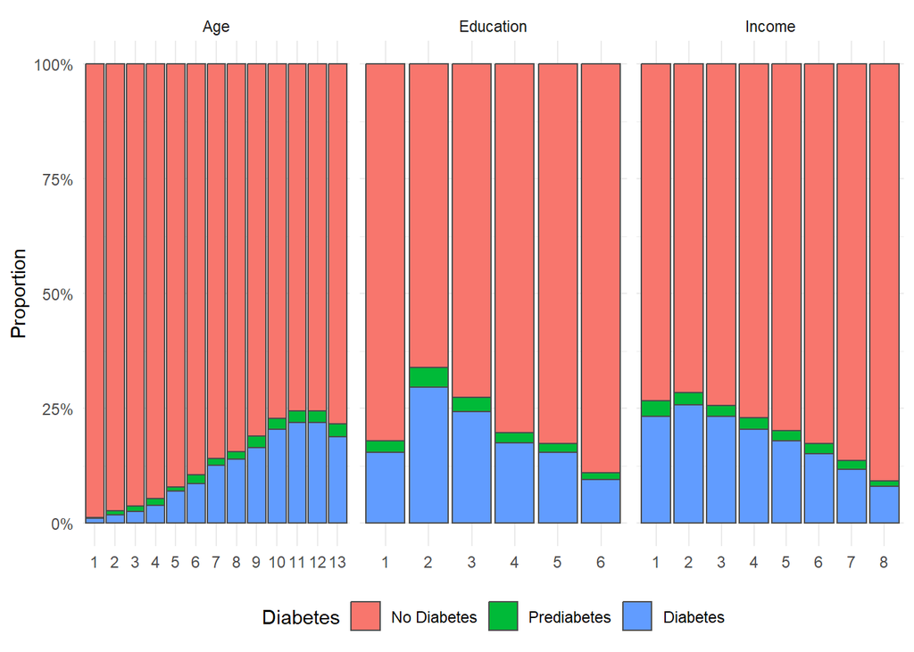

```r
ordinal_vars <- c("Age","Education","Income")

df_long_ord <- df %>%
  mutate(
    Diabetes_012 = case_when(
      as.character(Diabetes_012) %in% c("0","No Diabetes") ~ "No Diabetes",
      as.character(Diabetes_012) %in% c("1","Prediabetes") ~ "Prediabetes",
      as.character(Diabetes_012) %in% c("2","Diabetes") ~ "Diabetes",
      TRUE ~ NA_character_
    ),
    Diabetes_012 = factor(Diabetes_012, levels = c("No Diabetes","Prediabetes","Diabetes"))
  ) %>%
  pivot_longer(
    cols = all_of(ordinal_vars),
    names_to = "Variable",
    values_to = "Value",
    values_transform = list(Value = ~ as.integer(as.character(.x)))  # <- clave
  ) %>%
  group_by(Variable) %>%
  mutate(Value = factor(Value, levels = sort(unique(Value), na.last = TRUE))) %>%
  ungroup()

ggplot(df_long_ord, aes(x = Value, fill = Diabetes_012)) +
  geom_bar(position = "fill", color = "grey30") +
  facet_wrap(~ Variable, scales = "free_x", ncol = 3) +
  scale_y_continuous(labels = percent_format()) +
  labs(x = NULL, y = "Proportion", fill = "Diabetes") +
  theme_minimal() +
  theme(legend.position = "bottom")
```

Education shows an inverse gradient. Lower educational attainment is associated with higher proportions of Diabetes and Prediabetes, whereas higher education levels correspond to a greater proportion of individuals without diabetes.

A similar inverse pattern is observed for Income. Individuals in lower income categories display higher proportions of Diabetes and Prediabetes, while higher income levels are associated with lower prevalence of these conditions.

## Correlation Analysis

We examine the correlation structure among the continuous numerical variables in order to identify potential multicollinearity issues and relationships between predictors.

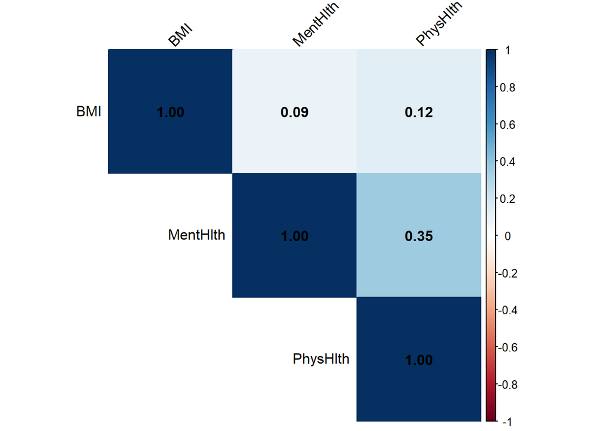

```r
num_vars <- df %>%
  dplyr::select(BMI, MentHlth, PhysHlth)

cor_matrix <- cor(num_vars, use = "complete.obs")

corrplot::corrplot(cor_matrix,
                   method = "color",
                   type = "upper",
                   addCoef.col = "black",
                   tl.col = "black",
                   tl.srt = 45)
```

### Correlation between numerical and Diabetes_012

```r
# Convert target to numeric (0,1,2)

num_vars <- c("BMI", "MentHlth", "PhysHlth")

eta_results <- sapply(num_vars, function(var) {
  model <- aov(as.formula(paste(var, "~ Diabetes_012")), data = df)
  eta_squared(model)$Eta2[1]
})

eta_results
```

```
        BMI    MentHlth    PhysHlth
0.053988144 0.004882973 0.030081853
```

### Correlation between categorical and Diabetes_012

```r
binary_vars <- c('HighBP','HighChol','CholCheck','Smoker',
                 'Stroke','HeartDiseaseorAttack','PhysActivity',
                 'Fruits','Veggies','HvyAlcoholConsump',
                 'AnyHealthcare','NoDocbcCost','DiffWalk','Sex')

cramer_results <- sapply(binary_vars, function(x) {
  tbl <- table(df[[x]], df$Diabetes_012)
  cramerV(tbl)
})

cramer_results
```

```
              HighBP.Cramer V             HighChol.Cramer V
                      0.27640                       0.20230
           CholCheck.Cramer V               Smoker.Cramer V
                      0.07117                       0.05996
              Stroke.Cramer V HeartDiseaseorAttack.Cramer V
                      0.10320                       0.17770
        PhysActivity.Cramer V               Fruits.Cramer V
                      0.12410                       0.04320
             Veggies.Cramer V    HvyAlcoholConsump.Cramer V
                      0.06514                       0.05605
       AnyHealthcare.Cramer V          NoDocbcCost.Cramer V
                      0.01248                       0.04108
            DiffWalk.Cramer V                  Sex.Cramer V
                      0.22690                       0.03577
```

```r
all_assoc <- c(eta_results, cramer_results)

sort(all_assoc, decreasing = TRUE)
```

```
              HighBP.Cramer V             DiffWalk.Cramer V
                  0.276400000                   0.226900000
            HighChol.Cramer V HeartDiseaseorAttack.Cramer V
                  0.202300000                   0.177700000
        PhysActivity.Cramer V               Stroke.Cramer V
                  0.124100000                   0.103200000
           CholCheck.Cramer V              Veggies.Cramer V
                  0.071170000                   0.065140000
              Smoker.Cramer V    HvyAlcoholConsump.Cramer V
                  0.059960000                   0.056050000
                          BMI               Fruits.Cramer V
                  0.053988144                   0.043200000
         NoDocbcCost.Cramer V                  Sex.Cramer V
                  0.041080000                   0.035770000
                     PhysHlth        AnyHealthcare.Cramer V
                  0.030081853                   0.012480000
                     MentHlth
                  0.004882973
```

To assess the relationship between each predictor and the response variable (Diabetes status), appropriate association measures were computed depending on the variable type. Cramer’s V was used for checking the relationship between categorical variables and `Diabetes_012`, while Eta squared was calculated for checking the relationship between numerical variables and `Diabetes_012.`

The coefficients were then ranked in descending order to identify which variables show the strongest association with diabetes status.

The results indicate that clinical and cardiovascular-related variables, such as High Blood Pressure and High Cholesterol, present the highest association values. In contrast, lifestyle and demographic variables tend to show weaker associations.

# Probabilistic Learning

In this project, we focus on probabilistic multiclass classification for diabetes status. Instead of predicting a single label directly, the models estimate class membership probabilities for each level in `Diabetes_012`, which lets us quantify uncertainty and compare decision rules via confusion matrices and ROC-style analyses. We will evaluate and compare the following models:

- **Multiclass Logistic Regression (baseline):** a multinomial model that estimates the log-odds of each diabetes category relative to a reference class as a linear function of the predictors.
- **Linear Discriminant Analysis (LDA):** models each class with a Gaussian distribution while assuming a common covariance matrix across classes.
- **Quadratic Discriminant Analysis (QDA):** relaxes LDA’s shared-covariance assumption by allowing a different covariance matrix for each class.
- **Naive Bayes:** estimates class probabilities using conditional independence between predictors given the class, providing a simple but often competitive baseline.

As mentioned earlier, our response variable `Diabetes_012` is imbalanced. As a result, these models will generally perform worse on the minority classes (in our case, class 1, which corresponds to Prediabetes), since the training objective tends to favor the majority class. We will first show how this imbalance affects classification performance, and then apply strategies to mitigate the issue.

## Data Splitting into Train/Test

We split the dataset into train and test sets using an 80/20 random split. The resulting partitions contain 40,000 observations for training and 10,000 observations for testing, and all models are fitted on the training set and evaluated using the test set.

```r
set.seed(123)
nrow <- nrow(df)
ncol <- ncol(df)

idx_train <- sample(nrow, size = floor(0.8 * nrow(df)))
train_data <- df[idx_train, ]    # Train set
test_data  <- df[-idx_train, ]   # Test set

cat("Training set size:", nrow(train_data), "\n")
```

```
Training set size: 40000
```

```r
cat("Test set size:", nrow(test_data), "\n")
```

```
Test set size: 10000
```

## Multiclass Logistic Regression

We include multiclass logistic regression as a baseline to benchmark the discriminant analysis methods and to make the impact of class imbalance explicit, highlighting how probability-based classifiers can achieve reasonable overall accuracy while still underperforming on the less frequent classes, which in our case play a very important role.

The model is estimated on the training set using a multinomial logistic regression with 5-fold cross-validation to obtain more robust performance estimates and reduce dependence on a single data split. The final fitted model is then used to predict diabetes status in the test set. Performance is evaluated using a confusion matrix, reporting overall accuracy as well as class-specific metrics such as sensitivity and specificity, which are particularly informative under class imbalance.

```r
#Function for multiclass logist regression to obtain the model, predictions and the confusion matrix
multinom_func <- function(train_data, test_data) {

  ctrl <- trainControl(method = "cv", number = 5)

  # 1. Fit multinomial logistic regression
  model <- train(Diabetes_012 ~ ., data = train_data,
                    method = "multinom", trace = FALSE,
                    trControl = ctrl)

  # 2. Predict class labels for the test set
  preds <- predict(model, newdata = test_data, type = 'raw')
  # 3. Generate the confusion matrix
  cm <- caret::confusionMatrix(preds, test_data$Diabetes_012)

  # 4. Return as a list so you can access each part later
  return(list(model = model, predictions = preds, confusion_matrix = cm))
}
```

```r
#---------------  Run Function ---------------
# Obtain the multinomial logistic regression for orginal sample
# with imbalance classes in the target.
results <- multinom_func(train_data, test_data)
```

### Analyzing the results

Now we analyze the Multinomial Logistic Regression output using the imbalance dataset.

```r
#---------------  Save Results ---------------
multi_model <- results$model
multinom_pred <- results$predictions
multi_cm <- results$confusion_matrix
multi_cm
```

```
Confusion Matrix and Statistics

          Reference
Prediction    0    1    2
         0 8220  186 1131
         1    0    0    0
         2  187   12  264

Overall Statistics

               Accuracy : 0.8484
                 95% CI : (0.8412, 0.8554)
    No Information Rate : 0.8407
    P-Value [Acc > NIR] : 0.01781

                  Kappa : 0.2095

 Mcnemar's Test P-Value : < 2e-16

Statistics by Class:

                     Class: 0 Class: 1 Class: 2
Sensitivity            0.9778   0.0000   0.1892
Specificity            0.1733   1.0000   0.9769
Pos Pred Value         0.8619      NaN   0.5702
Neg Pred Value         0.5961   0.9802   0.8814
Prevalence             0.8407   0.0198   0.1395
Detection Rate         0.8220   0.0000   0.0264
Detection Prevalence   0.9537   0.0000   0.0463
Balanced Accuracy      0.5755   0.5000   0.5831
```

The result is a direct consequence of the strong class imbalance in the dataset, where more than 84% of observations belong to the majority class. In such contexts, high overall accuracy can be achieved even if the model performs poorly on minority classes. Therefore, accuracy alone is not an adequate measure of performance.

For the Prediabetes class, the model completely fails to detect any observations (sensitivity = 0%). It never predicts this category, resulting in a balanced accuracy of 0.50, equivalent to random classification. This indicates that the model does not learn a meaningful decision boundary for this rare class.

A Kappa value of 0.21 indicates weak agreement between predicted and true classes after correcting for chance agreement. This confirms that the model’s performance, beyond what would be expected due to the dominant class alone, is relatively poor.

Overall, these results demonstrate that multinomial logistic regression, when applied without any correction for class imbalance, tends to favor the majority class and performs poorly in detecting minority classes. Therefore, accuracy alone is not an adequate metric in this setting, and class-specific measures such as sensitivity and balanced accuracy provide a more informative assessment of model performance.

## Resampling (Undersampling and Oversampling)

To address the strong class imbalance, we apply resampling on the training set so that the classifier is trained on a more balanced class distribution. We compare four settings: no resampling (baseline), random undersampling, random oversampling, and SMOTE (Synthetic Minority Over-sampling Technique), using multinomial logistic regression as the common model.

With undersampling, we randomly reduce the number of the majority class observations to match the minority class size. This often increases minority-class recall, but it can also remove informative majority-class examples and increase variance. On the other hand, with oversampling, we randomly replicate minority-class observations until they match the majority class size. This can improve sensitivity for rare classes, but it may increase overfitting because duplicated observations can make patterns look more “certain” than they really are. Finally, SMOTE differs from simple oversampling by generating synthetic minority-class observations instead of duplicating existing ones, aiming to improve minority-class detection while maintaining greater variability in the data.

Each resampled training set is used to fit the same multinomial model under identical cross-validation settings, and performance is evaluated on the unchanged test set. Beyond overall accuracy, we emphasize balanced accuracy and class-specific sensitivity to assess how well the model identifies prediabetes and diabetes cases under class imbalance.

### Undersampling (downsampling) and Oversampling (upsampling)

```r
#--------------- 1. Prepare Data for Resampling ---------------
# We use all features since the goal is model improvement
train_x <- train_data %>% dplyr::select(-Diabetes_012)
train_y <- train_data$Diabetes_012

#--------------- 2. Perform Resampling ---------------
# Downsampling: Reduces Class 0 and 2 to match the size of Class 1
train_down <- caret::downSample(x = train_x, y = train_y,
                                yname = "Diabetes_012")

# Upsampling: Increases Class 1 and 2 to match the size of Class 0
train_up <- caret::upSample(x = train_x, y = train_y,
                            yname = "Diabetes_012")

#--------------- 3. Train Models ---------------
results_down <- multinom_func(train_down, test_data)
results_up <- multinom_func(train_up, test_data)
```

```r
#--------------- Save Results ---------------
#--------------- Model ---------------
multi_model_down <- results_down$model
multi_model_up<- results_up$model

#---------------  Predictions ---------------
pred_base <- multinom_pred
pred_down <- results_down$predictions
pred_up   <- results_up$predictions

#--------------- Confusion Matrices ---------------
cm_base <- results$confusion_matrix
cm_down <- results_down$confusion_matrix
cm_up <- results_up$confusion_matrix
```

### SMOTE

```r
ctrl_smote <- trainControl(method = 'cv', number = 5, sampling = 'smote')

multi_mod_smote <- train(Diabetes_012 ~ .,
                            data = train_data,
                            method = 'multinom',
                            trace = FALSE,
                            trControl = ctrl_smote)
```

```r
#--------------- Save Results ---------------
multi_model_smote <- multi_mod_smote
pred_smote <- predict(multi_model_smote, newdata = test_data, type = 'raw')
levels(test_data$Diabetes_012) <- c("0", "1", "2")
cm_smote <- caret::confusionMatrix(pred_smote, test_data$Diabetes_012)
```

### Comparison of the resampling methods

Now, we are going to analyze and compare the obtained results:

```r
suppressPackageStartupMessages(library(rmarkdown))
get_metrics_multiclass <- function(cm) {
    by <- as.data.frame(cm$byClass)

    get_row <- function(pattern) {
        idx <- grep(pattern, rownames(by), ignore.case = TRUE)
        if (length(idx) == 0) return(NA_integer_)
        idx[1]
    }

    # column names can vary slightly; be defensive
    precision_col <- if ('Pos Pred Value' %in% names(by)) 'Pos Pred Value' else 'Precision'

    sens <- by$Sensitivity
    spec <- by$Specificity
    prec <- by[[precision_col]]

    idx_pre <- get_row('Prediabetes')
    idx_dia <- get_row('Diabetes')

    tibble::tibble(
        Accuracy = as.numeric(cm$overall['Accuracy']),
        Sensitivity = mean(sens, na.rm = TRUE),
        Specificity = mean(spec, na.rm = TRUE),
        Precision = mean(prec, na.rm = TRUE),
        Sens_Prediabetes = if (!is.na(idx_pre)) unname(sens[idx_pre]) else NA_real_,
        Sens_Diabetes = if (!is.na(idx_dia)) unname(sens[idx_dia]) else NA_real_
    )
}

resampling_results <- dplyr::bind_rows(
    get_metrics_multiclass(cm_base) %>% dplyr::mutate(Strategy = 'No resampling'),
    get_metrics_multiclass(cm_down) %>% dplyr::mutate(Strategy = 'Downsampling'),
    get_metrics_multiclass(cm_up) %>% dplyr::mutate(Strategy = 'Oversampling'),
    get_metrics_multiclass(cm_smote) %>% dplyr::mutate(Strategy = 'SMOTE')
) %>%
    dplyr::select(
        Strategy,
        Accuracy,
        Sensitivity,
        Specificity,
        Precision,
        Sens_Prediabetes,
        Sens_Diabetes
    )

knitr::kable(resampling_results, booktabs = TRUE) # to display better the table
```

| Strategy | Accuracy | Sensitivity | Specificity | Precision | Sens_Prediabetes | Sens_Diabetes |
| --- | --- | --- | --- | --- | --- | --- |
| No resampling | 0.8484 | 0.3890013 | 0.7167106 | 0.7160503 | NA | NA |
| Downsampling | 0.6157 | 0.5184316 | 0.8126610 | 0.4435660 | NA | NA |
| Oversampling | 0.6323 | 0.5228226 | 0.8166295 | 0.4449449 | NA | NA |
| SMOTE | 0.6264 | 0.5181426 | 0.8151633 | 0.4438073 | NA | NA |

The comparison of resampling strategies highlights the trade-off between overall accuracy and minority-class detection. As discussed earlier, the high accuracy without resampling is mainly driven by the dominance of the majority class and therefore does not reflect balanced performance across the three categories.

Introducing resampling substantially changes the results. While overall accuracy decreases for downsampling, oversampling, and SMOTE (to approximately 62–63%), macro sensitivity (sensitivity column of the table) improves considerably. In particular, macro sensitivity refers to the unweighted average of class-specific sensitivities (recall)

$$\text{Macro Sensitivity} = \frac{Sens_\text{No Diabetes} + Sens_\text{Prediabetes} + Sens_\text{Diabetes}}{3}.$$

Unlike overall accuracy, macro sensitivity treats each class equally regardless of its size, making it a more honest measure of balanced performance. The improvement here signals that the model is doing a better job of actually identifying cases across all groups rather than defaulting to the majority class.

Overall, we have seen that resampling shifts the model’s priorities, sacrificing some overall accuracy in exchange for better coverage of the classes that matter most clinically. Among the evaluated methods, random oversampling provides the best balance between minority-class detection and overall performance, so we will use it for the subsequent analysis.

Below we can see the confusion matrix of the multinomial logistic regression model with oversampling:

```r
# ---- confusion matrix ----
cm_up
```

```
Confusion Matrix and Statistics

          Reference
Prediction    0    1    2
         0 5436   63  229
         1 1527   66  345
         2 1444   69  821

Overall Statistics

               Accuracy : 0.6323
                 95% CI : (0.6228, 0.6418)
    No Information Rate : 0.8407
    P-Value [Acc > NIR] : 1

                  Kappa : 0.2372

 Mcnemar's Test P-Value : <2e-16

Statistics by Class:

                     Class: 0 Class: 1 Class: 2
Sensitivity            0.6466  0.33333   0.5885
Specificity            0.8167  0.80902   0.8242
Pos Pred Value         0.9490  0.03406   0.3518
Neg Pred Value         0.3045  0.98363   0.9251
Prevalence             0.8407  0.01980   0.1395
Detection Rate         0.5436  0.00660   0.0821
Detection Prevalence   0.5728  0.19380   0.2334
Balanced Accuracy      0.7317  0.57118   0.7064
```

## Linear Discriminant Analysis (LDA)

In our case, LDA models the predictors for each diabetes category in `Diabetes_012` as coming from a multivariate normal distribution and assumes that all classes share the same covariance structure. Under these assumptions, the method produces linear decision boundaries between the three classes, making it a relatively simple and interpretable probabilistic classifier. The model is trained on the randomly oversampled training set to mitigate class imbalance, and its performance is evaluated using 5-fold cross-validation to obtain more robust estimates.

- **Prior probabilities** are the class proportions in the training set. With the imbalanced dataset, the larger classes would get higher priors by default, biasing LDA toward predicting the majority class. This is why we address the class imbalance before applying the method.
- **Group means** are the per-class averages of each predictor, that is, the estimated class “centers” in feature space.
- **Scaling coefficients** (the discriminant loadings) define the linear combinations of predictors that form the discriminant axes used to separate the classes.
- **Geometric view:** under the shared-covariance assumption, LDA classifies a point by comparing how close it is to each class center using Mahalanobis distance computed with the pooled covariance matrix (and, more generally, it also shifts the decision boundaries according to the class priors).

```r
lda_func <- function(train_data, test_data) {

  ctrl <- trainControl(method = "cv", number = 5)
  # ---------------- LDA model ----------------

  model <- caret::train(Diabetes_012 ~ .,
                       data = train_data,
                       method = "lda",
                       trControl = ctrl)

  # ---------------- Predictions ----------------
  pred <- predict(model, newdata = test_data)

  # Confusion matrix
  cm <- caret::confusionMatrix(pred, test_data$Diabetes_012)

  return(list(
    model = model,
    predictions = pred,
    confusion_matrix = cm
  ))
}
```

```r
#---------------  Run Function ---------------
lda_results_up <- lda_func(train_up, test_data)
```

### Analyzing the results

Now we analyze the LDA output by examining the class priors, group means, discriminant scaling coefficients, and the confusion matrix to understand both the model’s assumptions and its classification performance.

```r
#--------------- Save Results ---------------
lda_up <- lda_results_up$model
lda_model_up <- lda_up$finalModel
lda_pred_up  <- lda_results_up$predictions
lda_cm_up    <- lda_results_up$confusion_matrix
```

```r
cat("Prior probabilities:\n")
```

```
Prior probabilities:
```

```r
print(round(lda_model_up$prior, 4))
```

```
     0      1      2
0.3333 0.3333 0.3333
```

The equal prior probabilities (0.333 for each class) indicate that, due to upsampling, the LDA model was trained on a balanced dataset and therefore assigns equal importance to all three classes instead of favoring the original majority class.

```r
cat("\nGroup means (first 6 variables):\n")
```

```
Group means (first 6 variables):
```

```r
print(round(lda_model_up$means[, 1:min(6, ncol(lda_model_up$means))], 3))
```

```
  HighBP1 HighChol1 CholCheck1    BMI Smoker1 Stroke1
0   0.370     0.380      0.956 27.712   0.429   0.032
1   0.642     0.626      0.982 30.598   0.484   0.047
2   0.756     0.655      0.993 31.977   0.507   0.089
```

The group means represent the average value of each predictor within each class and show how the variables differ across diabetes categories. For example, the mean values of HighBP1, HighChol1, BMI, and Stroke1 increase from No Diabetes to Prediabetes and are highest for Diabetes. This pattern suggests that these risk factors are positively associated with disease severity and contribute to the separation of the classes in the LDA model.

```r
cat("\nLinear discriminant coefficients (first 10 variables):\n")
```

```
Linear discriminant coefficients (first 10 variables):
```

```r
print(round(lda_model_up$scaling[1:min(10, nrow(lda_model_up$scaling)), ], 4))
```

```
                          LD1     LD2
HighBP1                0.6500  0.0046
HighChol1              0.4328 -0.6567
CholCheck1             0.8784 -0.0862
BMI                    0.0484  0.0049
Smoker1               -0.0685 -0.0559
Stroke1                0.1254  0.9516
HeartDiseaseorAttack1  0.2088  0.9011
PhysActivity1         -0.0395 -0.3131
Fruits1               -0.0139 -0.1468
Veggies1              -0.0459  0.2572
```

The linear discriminant coefficients represent the weights assigned to each predictor in the discriminant functions. Larger absolute values indicate a stronger contribution to class separation, while the sign determines the direction of the relationship.

```r
# ---- Variable importance for LD1 and LD2 ----
get_ld_importance <- function(lda_model, ld_name) {
  contrib <- abs(lda_model$scaling[, ld_name])

  tibble::tibble(
    Variable = names(contrib),
    Contribution = round(contrib, 4)
  ) %>%
    dplyr::arrange(dplyr::desc(Contribution)) %>%
    dplyr::slice(1:10)
}

ld1_table <- get_ld_importance(lda_model_up, 'LD1')
ld2_table <- get_ld_importance(lda_model_up, 'LD2')

knitr::kable(ld1_table,
             booktabs = TRUE,
             digits = 4)
```

| Variable | Contribution |
| --- | --- |
| Age.L | 1.8861 |
| GenHlth5 | 1.5400 |
| GenHlth4 | 1.5338 |
| GenHlth3 | 1.2698 |
| CholCheck1 | 0.8784 |
| Education.Q | 0.6701 |
| HighBP1 | 0.6500 |
| GenHlth2 | 0.6412 |
| Education.L | 0.5663 |
| HvyAlcoholConsump1 | 0.4822 |

**LD1 table:** The first discriminant function (LD1) is primarily driven by age and general health indicators (Age.L, GenHlth4–5), followed by cholesterol checks and blood pressure, suggesting that overall health status and cardiovascular risk factors are the main dimensions separating the classes along this axis.

```r
knitr::kable(ld2_table,
             booktabs = TRUE,
             digits = 4)
```

| Variable | Contribution |
| --- | --- |
| Age.C | 1.3187 |
| Age^11 | 1.1747 |
| GenHlth5 | 1.0957 |
| Age.L | 1.0657 |
| Education.L | 0.9886 |
| Stroke1 | 0.9516 |
| HeartDiseaseorAttack1 | 0.9011 |
| Age^12 | 0.8744 |
| AnyHealthcare1 | 0.8225 |
| NoDocbcCost1 | 0.7973 |

**LD2 table:** The second discriminant function (LD2) is strongly influenced by age components, general health, education, and cardiovascular conditions (heart disease and stroke), indicating that this axis captures additional variation related to health severity and socio-demographic factors that further differentiate the diabetes categories.

```r
# ---- confusion matrix ----
lda_cm_up
```

```
Confusion Matrix and Statistics

          Reference
Prediction    0    1    2
         0 5293   62  214
         1 1763   73  404
         2 1351   63  777

Overall Statistics

               Accuracy : 0.6143
                 95% CI : (0.6047, 0.6239)
    No Information Rate : 0.8407
    P-Value [Acc > NIR] : 1

                  Kappa : 0.2237

 Mcnemar's Test P-Value : <2e-16

Statistics by Class:

                     Class: 0 Class: 1 Class: 2
Sensitivity            0.6296  0.36869   0.5570
Specificity            0.8267  0.77892   0.8357
Pos Pred Value         0.9504  0.03259   0.3546
Neg Pred Value         0.2972  0.98389   0.9209
Prevalence             0.8407  0.01980   0.1395
Detection Rate         0.5293  0.00730   0.0777
Detection Prevalence   0.5569  0.22400   0.2191
Balanced Accuracy      0.7282  0.57380   0.6963
```

### Graphical Representation

Some decisions had to be taken regarding model training for visualization. We trained a second LDA model uisng `MASS::lda()` extract the discriminant coordinates (LD1 and LD2) only for visualization. The performance evaluation remains based on the cross-validated `caret` model. Since both implementations use the same LDA methodology and training data, this does not affect the results or their interpretation.

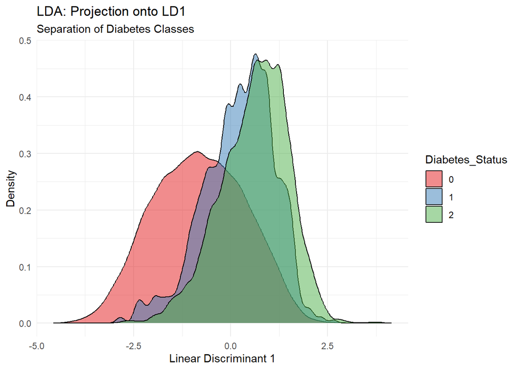

```r
#---------------Visualizing the Linear Discriminant----------------
# Project data onto the linear discriminant

# Train LDA directly using MASS (for visualization only)
lda_model_viz <- MASS::lda(Diabetes_012 ~ ., data = train_up)

lda_values <- predict(lda_model_viz, train_up)

lda_viz <- data.frame(
  LD1 = lda_values$x[, 1],
  LD2 = if (ncol(lda_values$x) > 1) lda_values$x[, 2] else NA,
  Diabetes_Status = train_up$Diabetes_012
)

# Since you have 3 classes, a 2D scatter plot of LD1 vs LD2 is usually
#more informative than a density plot, but I have provided both options below.

# Option A: Density Plot of the first Discriminant (LD1)
ggplot(lda_viz, aes(x = LD1, fill = Diabetes_Status)) +
  geom_density(alpha = 0.5) +
  labs(title = "LDA: Projection onto LD1",
       subtitle = "Separation of Diabetes Classes",
       x = "Linear Discriminant 1",
       y = "Density") +
  theme_minimal() +
  scale_fill_brewer(palette = "Set1")
```

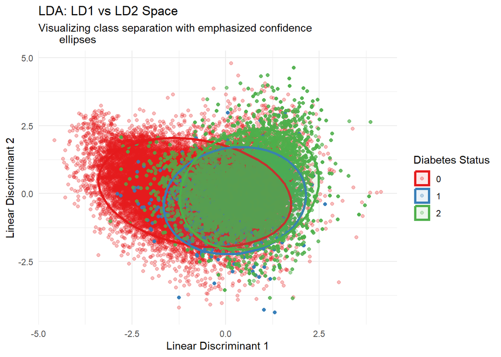

```r
# Scatter plot of LD1 vs LD2
ggplot(lda_viz, aes(x = LD1, y = LD2, color = Diabetes_Status)) +
  # 1. Plot the points with transparency (alpha) to keep the "cloud" look
  geom_point(alpha = 0.3) +

  # 2. Add thick, solid ellipses
  # 'linewidth' makes the lines thicker
  # 'level = 0.95' is the confidence level (standard)
  stat_ellipse(aes(fill = Diabetes_Status),
               geom = "polygon",
               alpha = 0.1,
               linewidth = 1.2) +

  # 3. Titles and Labels
  labs(title = "LDA: LD1 vs LD2 Space",
       subtitle = "Visualizing class separation with emphasized confidence
       ellipses",
       x = "Linear Discriminant 1",
       y = "Linear Discriminant 2",
       color = "Diabetes Status",
       fill = "Diabetes Status") +

  # 4. Styling
  theme_minimal() +
  scale_color_brewer(palette = "Set1") +
  scale_fill_brewer(palette = "Set1")
```

## Quadratic Discriminant Analysis (QDA)

QDA models the predictors for each diabetes category in `Diabetes_012` as coming from a multivariate normal distribution, but unlike LDA it allows each class to have its own covariance matrix. This extra flexibility leads to quadratic (non-linear) decision boundaries between the three classes, which can capture more complex separation patterns, at the cost of estimating more parameters and potentially overfitting when data are limited or highly imbalanced. We train the QDA model on the randomly oversampled training set to reduce class imbalance and improve minority-class detection, using 5-fold cross-validation to obtain more robust performance estimates.

```r
qda_func <- function(train_data, test_data) {

  ctrl <- trainControl(method = "cv", number = 5)
  # ---------------- QDA model ----------------

  model <- caret::train(Diabetes_012 ~ .,
                       data = train_data,
                       method = "qda",
                       trControl = ctrl)

  # ---------------- Predictions ----------------
  pred <- predict(model, newdata = test_data)

  # Confusion matrix
  cm <- caret::confusionMatrix(pred, test_data$Diabetes_012)

  return(list(
    model = model,
    predictions = pred,
    confusion_matrix = cm
  ))
}
```

```r
#---------------  Run Function ---------------
qda_results_up <- qda_func(train_up, test_data)
```

### Analyzing the results

Now we analyze the QDA output by looking at the class priors, group means, and the confusion matrix to interpret the model’s behavior and evaluate its classification performance. Unlike LDA, QDA does not provide a single set of discriminant scaling coefficients, since it relies on class-specific covariance matrices and therefore produces quadratic decision boundaries.

```r
#--------------- Save Results ---------------
qda_up <- qda_results_up$model
qda_model_up <- qda_up$finalModel
qda_pred_up  <- qda_results_up$predictions
qda_cm_up    <- qda_results_up$confusion_matrix
```

```r
cat("Prior probabilities:\n")
```

```
Prior probabilities:
```

```r
print(round(qda_model_up$prior, 4))
```

```
     0      1      2
0.3333 0.3333 0.3333
```

Similarly to LDA, the equal prior probabilities (0.333 for each class) indicate that, due to oversampling, the QDA model assigns equal importance to all three classes.

```r
cat("\nGroup means (first 6 variables):\n")
```

```
Group means (first 6 variables):
```

```r
print(round(qda_model_up$means[, 1:min(6, ncol(qda_model_up$means))], 3))
```

```
  HighBP1 HighChol1 CholCheck1    BMI Smoker1 Stroke1
0   0.370     0.380      0.956 27.712   0.429   0.032
1   0.642     0.626      0.982 30.598   0.484   0.047
2   0.756     0.655      0.993 31.977   0.507   0.089
```

The group means represent the average value of each predictor within each diabetes category under the QDA model. The results show a consistent increasing pattern across classes for several risk factors: HighBP1, HighChol1, BMI, Smoker1, and Stroke1 are lowest for No Diabetes, higher for Prediabetes, and highest for Diabetes. This gradual increase suggests a strong association between these health-related factors and disease progression. In contrast, CholCheck1 exhibits very similar mean values across all three groups, indicating that it contributes less to class separation compared to the cardiovascular and lifestyle-related variables.

```r
# ---- confusion matrix ----
qda_cm_up
```

```
Confusion Matrix and Statistics

          Reference
Prediction    0    1    2
         0 4682   58  159
         1  454   20   93
         2 3271  120 1143

Overall Statistics

               Accuracy : 0.5845
                 95% CI : (0.5748, 0.5942)
    No Information Rate : 0.8407
    P-Value [Acc > NIR] : 1

                  Kappa : 0.2067

 Mcnemar's Test P-Value : <2e-16

Statistics by Class:

                     Class: 0 Class: 1 Class: 2
Sensitivity            0.5569  0.10101   0.8194
Specificity            0.8638  0.94420   0.6059
Pos Pred Value         0.9557  0.03527   0.2521
Neg Pred Value         0.2698  0.98113   0.9539
Prevalence             0.8407  0.01980   0.1395
Detection Rate         0.4682  0.00200   0.1143
Detection Prevalence   0.4899  0.05670   0.4534
Balanced Accuracy      0.7103  0.52260   0.7126
```

Overall, while QDA improves detection of Diabetes compared to previous models, it does not meaningfully improve identification of Prediabetes and underperforms LDA with oversampling. The model’s additional flexibility, through class-specific covariance matrices, does not translate into clear performance gains and may introduce instability due to the higher number of parameters. In practice, QDA favors minority-class detection for Diabetes but sacrifices overall balance and fails to address the challenge of detecting rare Prediabetes cases.

### Graphical Results

To visualize QDA predictions, we projected the data onto the first two linear discriminants from LDA. Since QDA doesn’t produce its own discriminant axes, this lets us show class separation in 2D while still reflecting the full QDA model trained on all predictors. Unlike limiting the model to two features, this preserves the information from the entire dataset.

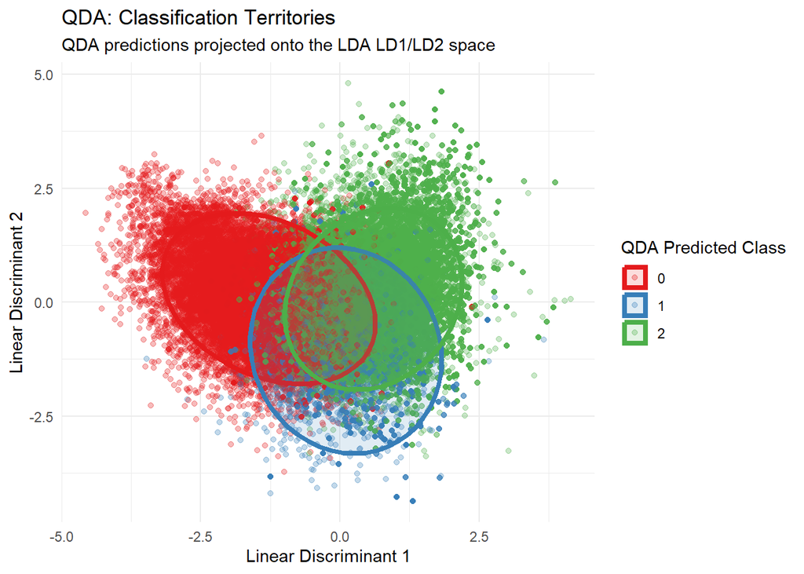

```r
#---------------Visualizing the Quadratic Discriminant----------------
# Use the same LDA projection for coordinates
lda_model_viz <- MASS::lda(Diabetes_012 ~ ., data = train_up)
lda_values <- predict(lda_model_viz, train_up)

# Predict QDA classes
qda_model_viz <- MASS::qda(Diabetes_012 ~ ., data = train_up)
qda_values <- predict(qda_model_viz, train_up)

# Build visualization dataframe
qda_viz <- data.frame(
  LD1 = lda_values$x[,1],
  LD2 = if (ncol(lda_values$x) > 1) lda_values$x[,2] else NA,
  QDA_Class = qda_values$class
)

# Plot QDA predictions in LDA space
ggplot(qda_viz, aes(x = LD1, y = LD2, color = QDA_Class)) +
  geom_point(alpha = 0.3) +
  stat_ellipse(aes(fill = QDA_Class),
               geom = "polygon",
               alpha = 0.15,
               linewidth = 1.5) +
  labs(title = "QDA: Classification Territories",
       subtitle = "QDA predictions projected onto the LDA LD1/LD2 space",
       x = "Linear Discriminant 1",
       y = "Linear Discriminant 2",
       color = "QDA Predicted Class",
       fill = "QDA Predicted Class") +
  theme_minimal() +
  scale_color_brewer(palette = "Set1") +
  scale_fill_brewer(palette = "Set1")
```

The plot displays each sample colored by its QDA predicted class, with ellipses outlining approximate class regions. It shows good separation between No Diabetes and Diabetes, while Prediabetes overlaps both, capturing its intermediate status. Overall, this provides a clear and faithful view of how QDA separates the classes in a reduced space.

## Naive Bayes

For Naive Bayes, we model *Diabetes_012* probabilistically by combining a prior for each diabetes class with class-conditional feature distributions. The key assumption is that predictors are conditionally independent given the class, so the posterior probability is obtained by multiplying the individual feature likelihoods with the prior. This makes Naive Bayes simple and fast, and it can work surprisingly well even when the independence assumption is not strictly true, but its performance can degrade when predictors are strongly correlated or when class imbalance dominates the priors. In our case, we train the model on the randomly oversampled training set to mitigate class imbalance and use 5-fold cross-validation to get more robust performance estimates.

```r
naiveBayes_func <- function(train_data, test_data) {

  ctrl <- trainControl(method = "cv", number = 5)
  # ----------------Naive Bayes model ----------------

  model <- caret::train(Diabetes_012 ~ .,
                      data = train_data,
                      method = "naive_bayes",
                      trControl = ctrl)

  # ---------------- Predictions ----------------
  pred <- predict(model, newdata = test_data)

  # Confusion matrix
  cm <- caret::confusionMatrix(pred, test_data$Diabetes_012)

  return(list(
    model = model,
    predictions = pred,
    confusion_matrix = cm
  ))
}
```

```r
#---------------  Run Function ---------------
nb_results_up <- naiveBayes_func(train_up, test_data)
```

### Analyzing the results

```r
#--------------- Save Results ---------------
nb_up <- nb_results_up$model
nb_model_up <-  nb_up$finalModel
nb_pred_up  <- nb_results_up$predictions
nb_cm_up    <- nb_results_up$confusion_matrix
```

```r
cat("Prior probabilities:\n")
```

```
Prior probabilities:
```

```r
print(round(nb_model_up$prior, 4))
```

```
     0      1      2
0.3333 0.3333 0.3333
```

The equal prior probabilities (0.333 for each class) indicate that, due to oversampling, the Naive Bayes model was trained on a balanced dataset and assigns equal initial weight to all three diabetes categories.

```r
# ---- confusion matrix ----
nb_cm_up
```

```
Confusion Matrix and Statistics

          Reference
Prediction    0    1    2
         0 5833   91  392
         1  852   31  165
         2 1722   76  838

Overall Statistics

               Accuracy : 0.6702
                 95% CI : (0.6609, 0.6794)
    No Information Rate : 0.8407
    P-Value [Acc > NIR] : 1

                  Kappa : 0.2333

 Mcnemar's Test P-Value : <2e-16

Statistics by Class:

                     Class: 0 Class: 1 Class: 2
Sensitivity            0.6938  0.15657   0.6007
Specificity            0.6968  0.89625   0.7911
Pos Pred Value         0.9235  0.02958   0.3179
Neg Pred Value         0.3013  0.98134   0.9244
Prevalence             0.8407  0.01980   0.1395
Detection Rate         0.5833  0.00310   0.0838
Detection Prevalence   0.6316  0.10480   0.2636
Balanced Accuracy      0.6953  0.52641   0.6959
```

Overall, Naive Bayes improves minority-class detection compared to the non-resampled model and performs more stably than QDA. Nevertheless, it continues to struggle with the rare Prediabetes class, highlighting the difficulty of separating this intermediate category.

## Model Comparison

We now evaluate and compare the four probabilistic models based on their predictive performance on the test set, where each model was trained on the randomly oversampled training data and tuned using 5-fold cross-validation. The comparison focuses not only on overall accuracy but also on class-specific and imbalance-robust metrics to assess their ability to detect prediabetes and diabetes cases.

```r
get_macro_metrics <- function(cm) {
  by <- as.data.frame(cm$byClass)

  tibble::tibble(
    Accuracy = as.numeric(cm$overall["Accuracy"]),
    Sensitivity = mean(by$Sensitivity, na.rm = TRUE),
    Specificity = mean(by$Specificity, na.rm = TRUE),
    Balanced_Accuracy = mean(by$`Balanced Accuracy`, na.rm = TRUE)
  )
}

comparison <- dplyr::bind_rows(
  get_macro_metrics(cm_up)      %>% dplyr::mutate(Method = "Logistic Regression"),
  get_macro_metrics(lda_cm_up)  %>% dplyr::mutate(Method = "LDA"),
  get_macro_metrics(qda_cm_up)  %>% dplyr::mutate(Method = "QDA"),
  get_macro_metrics(nb_cm_up)   %>% dplyr::mutate(Method = "Naive Bayes")
) %>%
  dplyr::select(Method,
                Accuracy,
                Sensitivity,
                Specificity,
                Balanced_Accuracy)

knitr::kable(comparison, booktabs = TRUE)
```

| Method | Accuracy | Sensitivity | Specificity | Balanced_Accuracy |
| --- | --- | --- | --- | --- |
| Logistic Regression | 0.6323 | 0.5228226 | 0.8166295 | 0.6697261 |
| LDA | 0.6143 | 0.5184235 | 0.8137805 | 0.6661020 |
| QDA | 0.5845 | 0.4924273 | 0.8046336 | 0.6485304 |
| Naive Bayes | 0.6702 | 0.4837030 | 0.7946986 | 0.6392008 |

**Model Performance Summary:** Overall, although **Naive Bayes** achieves the highest accuracy, **Multinomial** **Logistic Regression** provides the best balance between sensitivity and specificity across all classes. **LDA** performs very similarly and represents a competitive alternative. **QDA**, despite its greater flexibility, does not outperform the simpler linear methods in this setting.

This is illustrated in the graph below:

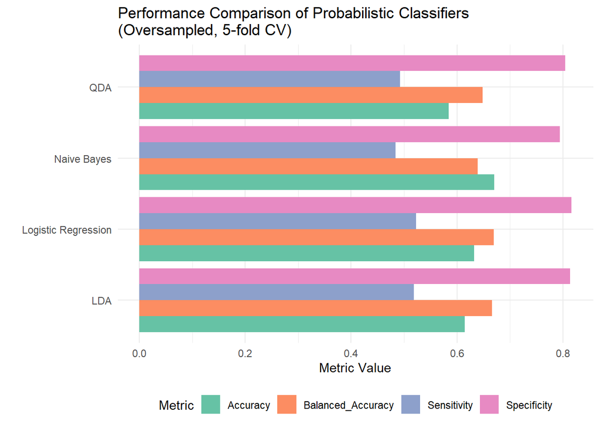

```r
comparison_long <- comparison %>%
  tidyr::pivot_longer(
    cols = c(Accuracy, Sensitivity, Specificity, Balanced_Accuracy),
    names_to = "Metric",
    values_to = "Value"
  )

ggplot(comparison_long, aes(x = Method, y = Value, fill = Metric)) +
  geom_col(position = "dodge") +
  labs(
    title = "Performance Comparison of Probabilistic Classifiers\n(Oversampled, 5-fold CV)",
    y = "Metric Value",
    x = ""
  ) +
  theme_minimal() +
  scale_fill_brewer(palette = "Set2") +
  coord_flip() +
  theme(legend.position = "bottom")
```

Based on the comparative results, Logistic Regression with oversampling is the preferred model. Although Naive Bayes achieves the highest overall accuracy, Logistic Regression provides the best balanced performance across classes. It attains the highest macro sensitivity and macro balanced accuracy, indicating a stronger and more consistent ability to detect all three diabetes categories.

In an imbalanced multiclass setting such as this one, overall accuracy can be misleading, and greater emphasis should be placed on metrics that evaluate performance more equitably across classes. Multiclass Logistic Regression offers the most stable trade-off between sensitivity and specificity while improving minority-class detection. Therefore, it is selected as the final model for subsequent analysis.

### Cross-Validation comparison

```r
cv_results <- resamples(list(
  Logistic_Regression = multi_model_up,
  LDA = lda_up,
  QDA = qda_up,
  Naive_Bayes = nb_up
))

summary(cv_results)
```

```
Call:
summary.resamples(object = cv_results)

Models: Logistic_Regression, LDA, QDA, Naive_Bayes
Number of resamples: 5

Accuracy
                         Min.   1st Qu.    Median      Mean   3rd Qu.      Max.
Logistic_Regression 0.5355408 0.5357922 0.5424577 0.5413879 0.5439718 0.5491771
LDA                 0.5321237 0.5344768 0.5380955 0.5389588 0.5425569 0.5475411
QDA                 0.5092946 0.5158140 0.5166568 0.5160267 0.5174243 0.5209438
Naive_Bayes         0.4986368 0.5005453 0.5022555 0.5018689 0.5029248 0.5049819
                    NA's
Logistic_Regression    0
LDA                    0
QDA                    0
Naive_Bayes            0

Kappa
                         Min.   1st Qu.    Median      Mean   3rd Qu.      Max.
Logistic_Regression 0.3033131 0.3036883 0.3136845 0.3120818 0.3159578 0.3237656
LDA                 0.2981856 0.3017165 0.3071433 0.3084382 0.3138341 0.3213117
QDA                 0.2639550 0.2737210 0.2749851 0.2740401 0.2761217 0.2814177
Naive_Bayes         0.2479508 0.2508180 0.2533763 0.2528032 0.2543873 0.2574834
                    NA's
Logistic_Regression    0
LDA                    0
QDA                    0
Naive_Bayes            0
```

We perform the model comparison not only on the test set but also using 5-fold cross-validation to obtain more robust estimates of predictive performance. Cross-validation averages performance across multiple resampled folds, reducing the influence of any single data split and giving a more stable assessment of model reliability.

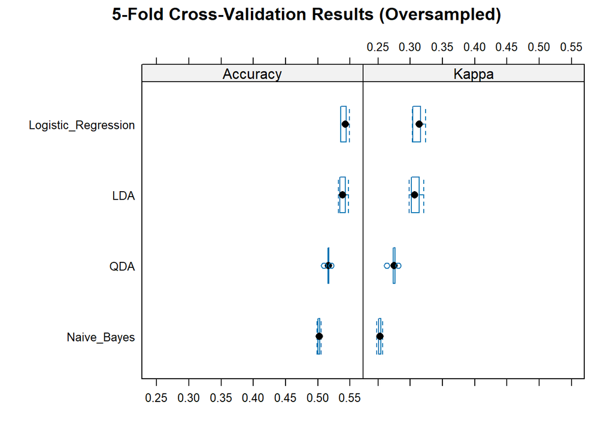

```r
bwplot(cv_results, main = "5-Fold Cross-Validation Results (Oversampled)")
```

# ROC Curves

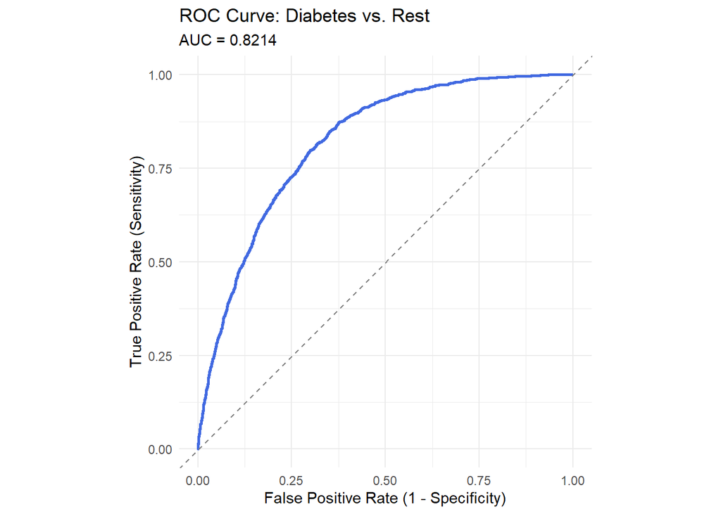

```r
# Prepare target variable and ensure levels are correctly mapped
test_data$Diabetes_012 <- as.factor(test_data$Diabetes_012)
levels(test_data$Diabetes_012) <- c("No Diabetes", "Prediabetes", "Diabetes")

# Get model probabilities and clean column names
multi_probs <- as.data.frame(predict(multi_model_up, newdata = test_data, type = "prob"))
colnames(multi_probs) <- c("No Diabetes", "Prediabetes", "Diabetes")

# Create a binary outcome: Diabetes vs. All Others (Rest)
y_bin <- factor(ifelse(test_data$Diabetes_012 == "Diabetes", "Diabetes", "No Diabetes"),
                levels = c("No Diabetes", "Diabetes"))

# Calculate ROC curve
roc_final <- roc(
  response = y_bin,
  predictor = multi_probs$Diabetes,
  levels = c("No Diabetes", "Diabetes"),
  direction = "<",
  quiet = TRUE
)

# Extract data for visualization
roc_data_final <- data.frame(
  Sensitivity = roc_final$sensitivities,
  Specificity = roc_final$specificities
)

# Plotting the ROC curve

ggplot(roc_data_final, aes(x = 1 - Specificity, y = Sensitivity)) +
  geom_line(linewidth = 1, color = "royalblue") +
  geom_abline(intercept = 0, slope = 1, linetype = "dashed", color = "gray50") +
  labs(
    title = "ROC Curve: Diabetes vs. Rest",
    subtitle = paste0("AUC = ", round(as.numeric(roc_final$auc), 4)),
    x = "False Positive Rate (1 - Specificity)",
    y = "True Positive Rate (Sensitivity)"
  ) +
  theme_minimal() +
  coord_equal()
```

Since missing a true diabetic or prediabetic case case (a false negative) is the bigger concern here, we want the model to lean toward sensitivity. Throughout the curve, the model stays well above the diagonal line that represents a random guess, which confirms it’s genuinely adding predictive value rather than just getting lucky.

# Effect of Threshold Selection

## Class Imbalance Problem

In such scenarios, a standard classifier optimized for overall accuracy tends to:

- Predict the majority class frequently.
- Achieve high accuracy.
- Miss a substantial number of positive cases (Diabetes).

From a medical perspective, misclassifying a patient with Diabetes as *No Diabetes* is considerably more severe than the reverse error. Therefore, accuracy alone is not an adequate performance criterion.

### Threshold Adjustment

Initially, we adjusted the decision rule by modifying the classification threshold.

Instead of assigning the predicted class as:

$\hat{y}(x) = \arg\max_k P(Y = k \mid x)$,

we explored lowering the probability threshold for positive cases in order to increase sensitivity.

Because the dataset is imbalanced, the default implicit threshold (selecting the maximum probability) often favors the majority class. Lowering the threshold increases detection of minority cases but reduces specificity. While this improves recall, it remains a heuristic adjustment and does not explicitly incorporate the asymmetric cost of errors.

### Cost-Sensitive Decision Rule

To formally account for asymmetric misclassification costs, we implemented a cost-sensitive decision rule.

Let:

- $P(Y = j \mid x)$ be the predicted posterior probability of class $j$
- $C_{j,k}$ be the cost of predicting class $k$ when the true class is $j$

The expected risk of predicting class $k$ for observation $x$ is:

$R(k \mid x) = \sum_{j=1}^{K} P(Y = j \mid x) \, C_{j,k}$

The optimal decision rule becomes:

$\hat{y}(x) = \arg\min_k R(k \mid x)$

Instead of selecting the class with maximum probability, we select the class that minimizes the expected misclassification cost.

### Cost Matrix Specification

We defined the following cost matrix:

$C =\begin{bmatrix} 0 & 1 & 1 \\1.5 & 0 & 0.5 \\3 & 1 & 0\end{bmatrix}$

Rows represent the true class, and columns represent the predicted class.

Key design principles:

- Misclassifying a true Diabetes case as No Diabetes (2 $→$ 0) carries the highest penalty (3), reflecting the clinical risk of missing a diabetic patient.
- Misclassifying Prediabetes as No Diabetes (1 $→$ 0) carries a moderate cost (1.5), acknowledging that underestimating intermediate risk is still undesirable.
- Confusing Diabetes with Prediabetes (2 $→$ 1) is penalized (1), but less severely than predicting No Diabetes.
- Overestimating severity (e.g., predicting Diabetes when the true class is No Diabetes or Prediabetes) is penalized (cost = 1 or 0.5), but at lower levels than false negatives for Diabetes.

This structure reflects a clinically informed hierarchy of errors: failing to detect Diabetes is considered more harmful than generating false positives, while intermediate missclassifications receive proportionate penalties.

Thus, these techniques improve minority class learning, increase sensitivity for Diabetes and reduce clinically harmful false negatives.

```r
test_data$Diabetes_012 <- factor(test_data$Diabetes_012,
                                 levels = c("No Diabetes","Prediabetes","Diabetes"))
probs3 <- predict(multi_model_up, newdata = test_data, type = "prob")

#Cost matrix
C <- matrix(
  c(
    0,  1,  1,
    1.5,  0,  0.5,
    3,  1,  0
  ),
  nrow = 3, byrow = TRUE
)
colnames(C) <- rownames(C) <- c("No Diabetes","Prediabetes","Diabetes")

risk <- as.matrix(probs3) %*% C
pred_cost <- colnames(risk)[max.col(-risk)]
pred_cost <- factor(pred_cost, levels = levels(test_data$Diabetes_012))

table(pred_cost)
```

```
pred_cost
No Diabetes Prediabetes    Diabetes
       3123        1178        5699
```

```r
cm_cost <- confusionMatrix(pred_cost, test_data$Diabetes_012)
cm_cost
```

```
Confusion Matrix and Statistics

             Reference
Prediction    No Diabetes Prediabetes Diabetes
  No Diabetes        3066          17       40
  Prediabetes        1082          22       74
  Diabetes           4259         159     1281

Overall Statistics

               Accuracy : 0.4369
                 95% CI : (0.4271, 0.4467)
    No Information Rate : 0.8407
    P-Value [Acc > NIR] : 1

                  Kappa : 0.1411

 Mcnemar's Test P-Value : <2e-16

Statistics by Class:

                     Class: No Diabetes Class: Prediabetes Class: Diabetes
Sensitivity                      0.3647            0.11111          0.9183
Specificity                      0.9642            0.88206          0.4866
Pos Pred Value                   0.9817            0.01868          0.2248
Neg Pred Value                   0.2234            0.98005          0.9735
Prevalence                       0.8407            0.01980          0.1395
Detection Rate                   0.3066            0.00220          0.1281
Detection Prevalence             0.3123            0.11780          0.5699
Balanced Accuracy                0.6645            0.49659          0.7024
```

The cost-sensitive model reaches an overall accuracy of 0.44, which remains below the No Information Rate due to the strong class imbalance (84% No Diabetes). The key result of this model is the very high sensitivity for the Diabetes class (0.91), meaning that the model successfully detects most true diabetic cases. This confirms that the cost-sensitive strategy effectively prioritizes reducing false negatives in the clinically critical class. As expected, this comes at the expense of lower specificity and precision for Diabetes, as well as reduced sensitivity for the majority class. This trade-off reflects the shift from maximizing overall accuracy to minimizing clinically harmful errors.

It is also important to note that, in a practical scenario, the cost matrix would be constructed with the assessment of health professionals who would better help us determine how “bad” it would be to wrongly predict each class and how important it is to correctly predict each class.